# Task 2: Parameter Estimation with Purrr - Lizards Length to Weight

Pol Carbó Mestre

February 7, 2022

```r
knitr::opts_chunk$set(echo = TRUE, message = F, warning = F, fig.align = "center")
```

```r
# Attach packages.
library(purrr)
library(here)
library(tidyverse)
library(Metrics)
library(cowplot)
library(ggtext)
library(kableExtra)
library(equatiomatic)
library(patchwork)
```

```r
lizard <- read_csv(here("data","lizard.csv"))
```

# Overview

This task aims to evaluate the best model fit using non-linear least squares to predict lizard’s weight based on snout length. The Lizard pitfall trap data used includes the species, the sex, the snout length, and the lizards’ weight.

**Data source:** Lightfoot, D. and W.G. Whitford. 2020. Lizard pitfall trap data from 11 NPP study locations at the Jornada Basin LTER site, 1989-2006 ver 37. Environmental Data Initiative. https://doi.org/10.6073/pasta/4a6e258fb49c31e222ecbbcfd128967f

# Model Fit

To fit a model using non-linear least squares to predict lizard’s weight based on its snout length, we will make use of the following function:

$$W=a(SVL)^b$$

## Finding the parameters

Since we know that the model is exponential, we can `log` transform our data to get an initial guess of the parameters that need to be fitted from the regression coefficients of a linear model.

$$y = a x^b$$
$$ln(y) = ln(a x^b)$$
$$ln(y) = ln(a) + b ·ln(x)$$

```r
lizard_log <- lizard %>%
  mutate(log_length = log(SV_length),
         log_weight = log(weight))
```

Once we transform the data, we can fit a linear model and get the first approximation for the parameters. To know the value of $a$ we will have to undo the log transformation, computing the `exp` of the intercept.

```r
my_guess_model <- lm(log_weight ~ log_length, data = lizard_log)

extract_eq(my_guess_model, wrap = TRUE, use_coefs = TRUE)
```

$$\begin{aligned}
\operatorname{\widehat{log\_weight}} &= -8.48 + 2.54(\operatorname{\log\_length})
\end{aligned}$$

From the previous model we establish that $a=$ 2.085246e-04 and $b=$ 2.5371187.

## Adjusting the model

Once we have a first approximation of the parameters, we will supply the non-linear least squares regression with them and fit the model with the original values of the dataset.

```r
lizard_fun<-function(a,b,SVL){
  W= a*SVL^b
  return(W)
  }

df_nls<-nls(weight~lizard_fun(a,b,SV_length),
            data=lizard,
            start=list(a=exp(coefficients(my_guess_model)[1]),
                       b=coefficients(my_guess_model)[2]),
            trace=TRUE )
```

Applying NLS we found that the final parameter values for our model are $a=$ 3.411133e-04 and $b=$ 2.4532065.

$$W=3.4·10^{-4}(SVL)^{2.45}$$

## Model visualization

Now we will visualize our fitted model on a plot with female and male lizards separated by color.

```r
length_series <- seq(0, 150, by = 0.1)
# Make predictions using the model over those times:
pred <- predict(df_nls, list(SV_length = length_series))
# Bind the predictions and age sequence together into a data frame:
predicted <- data.frame(length_series, pred)
```

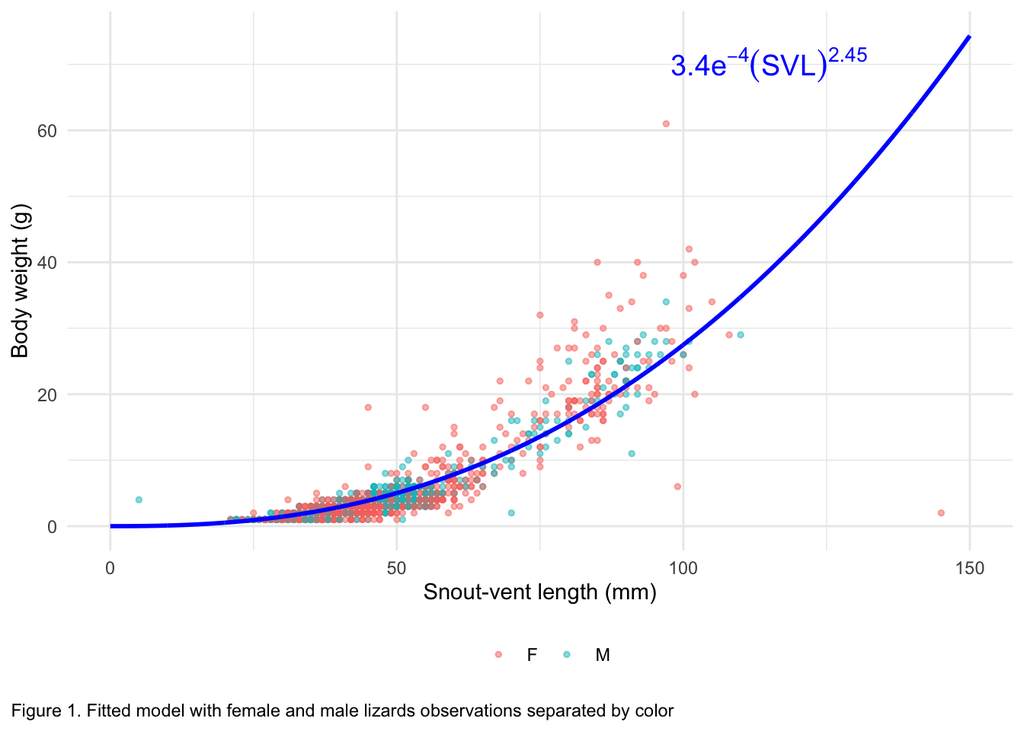

```r
ggplot() +
  geom_point(data = lizard,
             aes(x = SV_length, y = weight, color=sex),
             size = 1,
             alpha = 0.5) +
  geom_line(data = predicted,
            aes(x = length_series, y = pred),
            color = "blue",
            size = 1) +
  annotate(geom= "text", x= 115, y=70, parse = TRUE,
           label = "3.4 * e ^ {-4} * (SVL) ^ {2.45}",
           size = 5, color= "blue")+
  theme_minimal()+
  labs( x = "Snout-vent length (mm)",
        y = "Body weight (g)",
        caption = "Figure 1. Fitted model with female and male lizards observations separated by color") +
  theme(legend.position = "bottom",
        legend.title = element_blank(),
        plot.caption = element_textbox_simple(margin = margin(10,0,0,0)),
        plot.caption.position = "plot")
```

```r
kable(broom::tidy(df_nls),
      booktabs = T,
      caption = "Table 1. NLS model summary") %>%
  kable_styling(c("striped", "hover"),full_width = FALSE) %>%
  column_spec(1, bold = T)
```

Table 1. NLS model summary

| term | estimate | std.error | statistic | p.value |
| --- | --- | --- | --- | --- |
| a | 0.0003411 | 0.0000400 | 8.538421 | 0 |
| b | 2.4532065 | 0.0269791 | 90.930011 | 0 |

# Alternative model

This section will use a reduced dataset including only male Western Whiptail lizards (Cnemidophorus tigrisatus) coded as `CNTI` to fit a new model.

```r
CNTI_males <- lizard %>%
  filter(spp=="CNTI") %>%
  filter(sex== "M")

CNTI_males_log <- CNTI_males %>%
  mutate(log_length = log(SV_length),
         log_weight = log(weight))

my_guess_model2 <- lm(log_weight ~ log_length, data = CNTI_males_log)
```

With the new subset created, we will follow the same previous steps to get a first approximation of the parameters, through which we get that $a=$ 1.204877e-04 and $b=$ 2.6981084. Again, with these values we supply the NLS regression.

```r
df_nls2<-nls(weight~lizard_fun(a,b,SV_length),
            data=CNTI_males,
            start=list(a=exp(coefficients(my_guess_model2)[1]),
                       b=coefficients(my_guess_model2)[2]),
            trace=TRUE )
```

For the alternative model we get the following parameters values: $a=$ 5.315662e-04 and $b=$ 2.3683013.

$$W=5.3·10^{-4}(SVL)^{2.37}$$

```r
kable(broom::tidy(df_nls2),
      booktabs = T,
      caption = "Table 2. NLS alternative model summary.") %>%
  kable_styling(c("striped", "hover"),full_width = FALSE) %>%
  column_spec(1, bold = T)
```

Table 2. NLS alternative model summary.

| term | estimate | std.error | statistic | p.value |
| --- | --- | --- | --- | --- |
| a | 0.0005316 | 0.0004288 | 1.239686 | 0.2192313 |
| b | 2.3683013 | 0.1800348 | 13.154689 | 0.0000000 |

# Model comparison

As indicated for the task, this section will compare the specific nls model to the general nls model for all species, based on Western Whiptail male data prediction. To do so, we can compute the RMSE of both models. We also can compare the fit of the models over that subset visually.

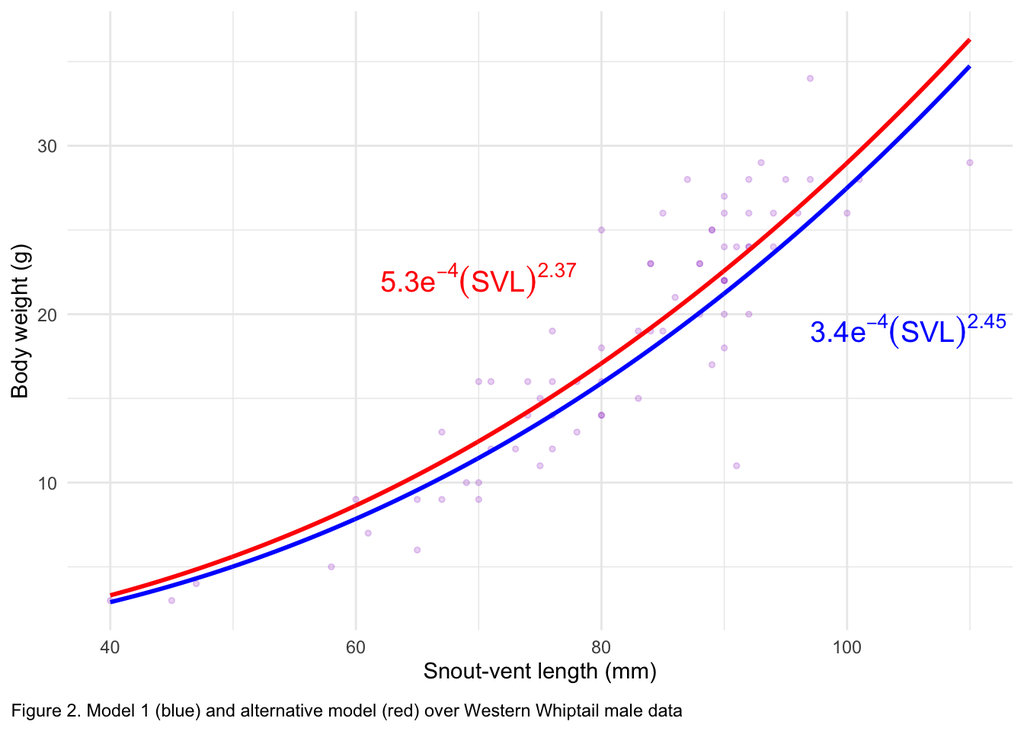

```r
length_seriesCNTI <- seq(40, 110, by = 0.1)
# Make predictions using the model over those times:
predCNTI <- predict(df_nls2, list(SV_length = length_seriesCNTI))
# Bind the predictions and age sequence together into a data frame:
predictedCNTI <- data.frame(length_seriesCNTI, predCNTI)

ggplot() +
  geom_point(data = CNTI_males,
             aes(x = SV_length, y = weight),
             size = 1,
             alpha = 0.2,color="darkorchid") +
  geom_line(data = predictedCNTI,
            aes(x = length_seriesCNTI, y = predCNTI),
            color = "red",
            size = 1) +
  geom_line(data = predicted[which(predicted == 40):which(predicted == 110),],
            aes(x = length_series, y = pred),
            color = "blue",
            size = 1) +
  annotate(geom= "text", x= 105, y=19, parse = TRUE,
           label = "3.4 * e ^ {-4} * (SVL) ^ {2.45}",
           size = 5, color= "blue") +
  annotate(geom= "text", x= 70, y=22, parse = TRUE,
           label = "5.3 * e ^ {-4} * (SVL) ^ {2.37}",
           size = 5, color= "red") +
  theme_minimal() +
  labs( x = "Snout-vent length (mm)",
        y = "Body weight (g)",
        caption = "Figure 2. Model 1 (blue) and alternative model (red) over Western Whiptail male data") +
  theme(legend.position = "bottom",
        legend.title = element_blank(),
        plot.caption = element_textbox_simple(margin = margin(10,0,0,0)),
        plot.caption.position = "plot")
```

As expected, it seems that the alternative models fit the data better. To evaluate it numerically, we can compute the RMSE of both models. Attending to the values, we can confirm that the specific nls model performs better than the general one.

```r
RMSE_summary <- data.frame("Model 1"=rmse(CNTI_males$weight, # full model
                                          predict(df_nls,list(SV_length=CNTI_males$SV_length))),
                           "Model 2"=rmse(CNTI_males$weight, # specific model
                                          predict(df_nls2,list(SV_length=CNTI_males$SV_length))))


kable(t(RMSE_summary),
      col.names = "RMSE",
      booktabs = T,
      caption = "Table 3. Model comparison using RMSE") %>%
  kable_styling(c("striped", "hover"),full_width = FALSE) %>%
  column_spec(1, bold = T)
```

Table 3. Model comparison using RMSE

|  | RMSE |
| --- | --- |
| Model.1 | 3.562172 |
| Model.2 | 3.349286 |

In the following figures, we can graphically see how the errors for the general nls model for all species are higher than the specific one when trying to predict Western Whiptail male weight.

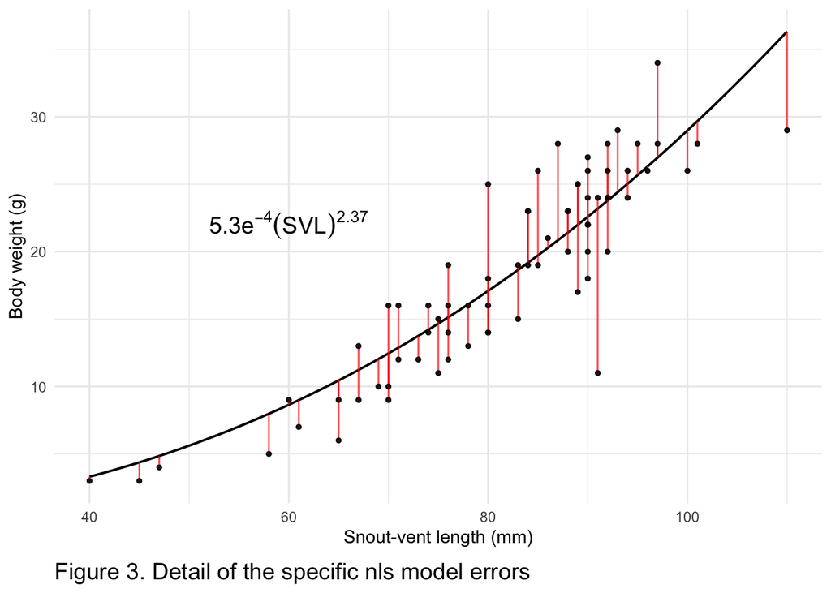

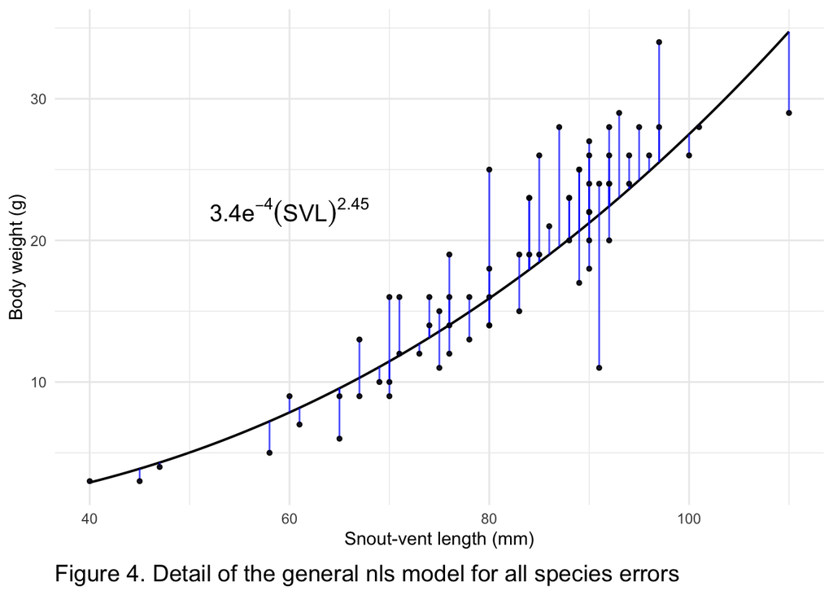

```r
# Merged data
predictedCNTI2.0 <- predictedCNTI %>%
  rename(SV_length = length_seriesCNTI)
merged_data <- merge(predictedCNTI2.0,CNTI_males,by="SV_length")

# Errors plot for the alternative model
ggplot(data = CNTI_males,
       aes(x = SV_length, y = weight)) +
  geom_point(size = 1,
             color="black",
             alpha=0.7) +
  geom_line(data = predictedCNTI,
            aes(x = length_seriesCNTI, y = predCNTI),
            color = "black",
            size = 0.7) +
  geom_segment(data=merged_data,
               aes(xend=SV_length, y=weight, yend=predCNTI),
               colour="red", size=0.5, alpha=0.7) +
  geom_point(size = 1,
             color="black",
             alpha=0.7) +
  annotate(geom= "text", x= 60, y=22, parse = TRUE,
           label = "5.3 * e ^ {-4} * (SVL) ^ {2.37}",
           size = 5, color= "black") +
  theme_minimal() +
  xlab('Snout-vent length (mm)')+
  ylab('Body weight (g)') +
  labs(caption = "Figure 3. Detail of the specific nls model errors") +
  theme(plot.caption = element_textbox_simple(size = 14,margin = margin(10,0,0,0)))


# Merged data
predicted2.0 <- predicted[which(predicted == 40):which(predicted == 110),] %>%
  rename(SV_length = length_series)
merged_data <- merge(predicted2.0,CNTI_males,by="SV_length")

# Errors plot for the alternative model
ggplot(data = CNTI_males,
       aes(x = SV_length, y = weight)) +
  geom_point(size = 1,
             color="black",
             alpha=0.7) +
  geom_line(data = predicted[which(predicted == 40):which(predicted == 110),],
            aes(x = length_series, y = pred),
            color = "black",
            size = 0.7) +
  geom_segment(data=merged_data,
               aes(xend=SV_length, y=weight, yend=pred),
               colour="blue", size=0.5, alpha=0.7) +
  geom_point(size = 1,
             color="black",
             alpha=0.7) +
  annotate(geom= "text", x= 60, y=22, parse = TRUE,
           label = "3.4 * e ^ {-4} * (SVL) ^ {2.45}",
           size = 5, color= "black") +
  theme_minimal() +
  xlab('Snout-vent length (mm)')+
  ylab('Body weight (g)') +
  labs(caption = "Figure 4. Detail of the general nls model for all species errors") +
  theme(plot.caption = element_textbox_simple(size = 14,margin = margin(10,0,0,0)))
```

Overall we can see how the specific model describes slightly better Western Whiptail males. Hence, we would choose this model to define the specific weights and the general one when describing the different species and sex as a whole.